# Pricing & Segmentation

BOUSSENGUI François - LEGER Aline

# Contexte et calibration des paramètres

Nous nous sommes placés dans le contexte d’un cinéma. Ce cinéma peut soit proposer des places vendues à l’unité, soit une formule fofaitaire permettant aux clients d’aller au cinéma autant de fois qu’ils le souhaitent sans payer de supplément ou proposer les deux formules.

En moyenne, nous pouvons dire que le prix d’un ticket de place de cinéma est fixé à 8€. Etant donné que l’ensemble des calculs dépendent du cout marginal, nous allons étudier comment une variation de ce dernier pourrait impacter les consommateurs et les producteurs.

Nous avons calibrer les paramètres fixes du modèle comme suit :

- l’utilité marginale de la monnaie : $h$=0.2
- le revenu : $R$=1000

Afin de fixer une plage de valeurs pour le coût marginal, nous nous sommes basé sur la formule à l’unité dont le prix est : $p=c+\frac{1}{h}$. Au vue du prix moyen d’une place de cinéma et de la valeur fixé pour l’uitlité marginale de la monnaie, nous avons pu déterminer les coûts marginaux qui nous permettent d’osciller autour du prix moyen: 2.5, 3 et 3.5.

Le paramètre de goût sera distribué selon une loi uniforme comprise entre 0 et 1.

Dans cette partie, nous allons donc étudier dans un premier temps le cas de la vente à l’unité, dans un second temps , celle de la vente forfaitaire et pour finir la comparaison entre ces deux stratégies de vente.

```r
set.seed(500)
theta<-sort(runif(15, min=0,max=1))
theta_barre<-1
h<-0.2
R = 1000
```

# Simulation avec loi uniforme (0,1)

## Cas de la vente à l’unité

Nous allons étudier la variation du profit, du surplus des consommateurs, du surplus total suite à une modification donc du coût marginal.

### Etude des différentes situations

| Type de consommateur | Demande individuelle | Utilité indirecte | Surplus individuel |
| --- | --- | --- | --- |
| 0.1643470 | 0.03318109 | 200.0332 | 0.1833539 |
| 0.2056958 | 0.04152927 | 200.0415 | 0.2294847 |
| 0.2820609 | 0.05694712 | 200.0569 | 0.3146815 |
| 0.4676038 | 0.09440759 | 200.0944 | 0.5216826 |
| 0.5121819 | 0.10340774 | 200.1034 | 0.5714161 |
| 0.7115770 | 0.14366493 | 200.1437 | 0.7938715 |
| 0.7250118 | 0.14637736 | 200.1464 | 0.8088600 |
| 0.7320744 | 0.14780327 | 200.1478 | 0.8167394 |
| 0.7647062 | 0.15439152 | 200.1544 | 0.8531451 |
| 0.8122781 | 0.16399613 | 200.1640 | 0.9062187 |

[output cut: 5 more lines]

Le profit du monopole est identique pour chaque consommateur étant donné que celui-ci ne dépend pas de $\theta$. Afin de déterminer le profit qu’il fait sur l’ensemble des consommateurs, nous allons sommer les profits fait sur chacun des consommateurs.

Le profit du monopole est donc de 0.335.

| Type de consommateur | Demande individuelle | Utilité indirecte | Surplus individuel |
| --- | --- | --- | --- |
| 0.1643470 | 0.03318109 | 200.0332 | 0.1659055 |
| 0.2056958 | 0.04152927 | 200.0415 | 0.2076464 |
| 0.2820609 | 0.05694712 | 200.0569 | 0.2847356 |
| 0.4676038 | 0.09440759 | 200.0944 | 0.4720379 |
| 0.5121819 | 0.10340774 | 200.1034 | 0.5170387 |
| 0.7115770 | 0.14366493 | 200.1437 | 0.7183246 |
| 0.7250118 | 0.14637736 | 200.1464 | 0.7318868 |
| 0.7320744 | 0.14780327 | 200.1478 | 0.7390164 |
| 0.7647062 | 0.15439152 | 200.1544 | 0.7719576 |
| 0.8122781 | 0.16399613 | 200.1640 | 0.8199806 |

[output cut: 5 more lines]

Le profit du monopole est donc de 0.303.

| Type de consommateur | Demande individuelle | Utilité indirecte | Surplus individuel |
| --- | --- | --- | --- |
| 0.1643470 | 0.03318109 | 200.0332 | 0.1501175 |
| 0.2056958 | 0.04152927 | 200.0415 | 0.1878862 |
| 0.2820609 | 0.05694712 | 200.0569 | 0.2576394 |
| 0.4676038 | 0.09440759 | 200.0944 | 0.4271176 |
| 0.5121819 | 0.10340774 | 200.1034 | 0.4678360 |
| 0.7115770 | 0.14366493 | 200.1437 | 0.6499670 |
| 0.7250118 | 0.14637736 | 200.1464 | 0.6622385 |
| 0.7320744 | 0.14780327 | 200.1478 | 0.6686897 |
| 0.7647062 | 0.15439152 | 200.1544 | 0.6984961 |
| 0.8122781 | 0.16399613 | 200.1640 | 0.7419492 |

[output cut: 5 more lines]

Le profit du monopole est donc de 0.274.

Résumé

|  | Prix | Cm | Profit |
| --- | --- | --- | --- |
| Situation 1 | 8 | 2.5 | 0.335 |
| Situation 2 | 8 | 3.0 | 0.303 |
| Situation 3 | 8 | 3.5 | 0.274 |

**De manière générale, on constate qu’au fur et à mesure que le coût marginal augmente (ce qui induit une augmentation du prix), le profit du monopole diminue.**

## Cas de la formule forfaitaire

Nous allons à présent déterminer le prix du forfait en fonction des mêmes coûts marginaux utilisés pour le cas de la vente à l’unité, à savoir : 2.5, 3 et 3.5.

### Etude des différentes situations

Cm=2.5

| Type de consommateur | Forfait | Demande individuelle | Utilité indirecte | Surplus individuel |
| --- | --- | --- | --- | --- |
| 0.7647062 | 3.33 | 0.7647062 | 200.0987 | 0.0980395 |
| 0.8122781 | 3.33 | 0.8122781 | 200.1463 | 0.1456115 |
| 0.8288314 | 3.33 | 0.8288314 | 200.1628 | 0.1621647 |
| 0.8336000 | 3.33 | 0.8336000 | 200.1676 | 0.1669333 |
| 0.8928427 | 3.33 | 0.8928427 | 200.2268 | 0.2261760 |
| 0.9254660 | 3.33 | 0.9254660 | 200.2595 | 0.2587994 |
| 0.9753142 | 3.33 | 0.9753142 | 200.3093 | 0.3086475 |

Le profit du monopole est donc de 2.917.

Cm=3

| Type de consommateur | Forfait | Demande individuelle | Utilité indirecte | Surplus individuel |
| --- | --- | --- | --- | --- |
| 0.8122781 | 3.57 | 0.8122781 | 200.0983 | 0.0979924 |
| 0.8288314 | 3.57 | 0.8288314 | 200.1148 | 0.1145457 |
| 0.8336000 | 3.57 | 0.8336000 | 200.1196 | 0.1193143 |
| 0.8928427 | 3.57 | 0.8928427 | 200.1788 | 0.1785570 |
| 0.9254660 | 3.57 | 0.9254660 | 200.2115 | 0.2111803 |
| 0.9753142 | 3.57 | 0.9753142 | 200.2613 | 0.2610284 |

Le profit du monopole est donc de 1.714.

Cm=3.5

| Type de consommateur | Forfait | Demande individuelle | Utilité indirecte | Surplus individuel |
| --- | --- | --- | --- | --- |
| 0.8928427 | 3.85 | 0.8928427 | 200.1228 | 0.1236119 |
| 0.9254660 | 3.85 | 0.9254660 | 200.1555 | 0.1562353 |
| 0.9753142 | 3.85 | 0.9753142 | 200.2053 | 0.2060834 |

Le profit du monopole est donc de 0.519.

Cm=4

| Type de consommateur | Forfait | Demande individuelle | Utilité indirecte | Surplus individuel |
| --- | --- | --- | --- | --- |
| 0.9254660 | 4.17 | 0.9254660 | 200.0915 | 0.0921327 |
| 0.9753142 | 4.17 | 0.9753142 | 200.1413 | 0.1419808 |

**De manière intuitive, plus le coût marginal augmente plus le forfait est élevé.** **On se rend compte que plus le coût marginal augmente, moins on a de gens qui participent au marché. Cela se traduit par la condition :**
$$\theta \geq \frac{hc + \overline{\theta}}{2}$$
**Plus le prix du forfait est élevé, moins il y a de consommateurs qui participent au marché et ceux qui participent au marché font moins de surplus plus le forfait est élevé.**

**Du côté des producteurs, plus le coût marginal augmente, plus le profit du producteur diminue, cela est probablement dû au fait qu’il y ait moins de consommateurs qui participent au marché.**

## Comparaison des deux stratégies

Nous allons donc comparer les deux stratégies en fonction du coût marginal.

Cm=2.5

|  | Vente à l’unité | Vente forfaitaire |
| --- | --- | --- |
| Profit | 0.3346952 | 2.916667 |
| Surplus consos | 10.9708541 | 1.366372 |
| Surplus social | 11.3055493 | 4.283039 |

Cm=3

|  | Vente à l’unité | Vente forfaitaire |
| --- | --- | --- |
| Profit | 0.3028448 | 1.7142857 |
| Surplus consos | 9.9268393 | 0.9826181 |
| Surplus social | 10.2296841 | 2.6969038 |

Cm=3.5

|  | Vente à l’unité | Vente forfaitaire |
| --- | --- | --- |
| Profit | 0.2740253 | 0.5192308 |
| Surplus consos | 8.9821756 | 0.4859306 |
| Surplus social | 9.2562009 | 1.0051614 |

**Concernant le surplus des consommateurs, on voit qu’il est toujours plus élevé dans le cas de la vente à l’unité que dans le cas de la vente forfaitaire. Cela peut en partie s’expliquer par le fait que tous les individus ne participent pas au marché dans le cas de la vente forfaitaire. Plus le coût marginal augmente, moins il y a d’individus qui participent au marché**

**Concernant le profit du monopole, nous pouvons voir que le profit provenant de la vente forfaitaire est toujours plus élevé par rapport à celui de la vente à l’unité. Cependant, plus le coût marginal augmente, moins l’écart entre les profits des deux stratégies de vente est important. On passe d’un écart de profit de 2.6 pour un Cm=2.5 à un écart de 0.3 pour un coût marginal de 3.5.**

Il pourrait être intéressant d’augmenter le coût marginal afin de voir si la vente à l’unité devient pus profitable que la vente forfaitaire.

Nous allons donc augmenter notre coût marginal à 4.

Cm=4

|  | Vente à l’unité | Vente forfaitaire |
| --- | --- | --- |
| Profit | 0.2479483 | 0.1666667 |
| Surplus consos | 8.1274086 | 0.2341135 |
| Surplus social | 8.3753569 | 0.4007802 |

**Pour un coût marginal de 4, la vente à l’unité devient plus profitable que la vente forfaitaire.**

## Vente à l’unité et à volonté

### Choix de la formule par les consommateurs

On détermine tout d’abord le consommateur indifférent. Ce dernier nous permettra de distinguer les individus qui préfèrent la vente à l’unité ou la vente forfaitaire.

$$\begin{aligned}
\overline{\theta} = \frac{hA}{1-exp(-hp)}
\end{aligned}$$

Nous nous plaçons dans la situation où le cout marginal = $3$ et le prix optimal $p$ = 8 et le forfait $A$ = 3.57.

Notre consommateur indifférent est donc : $\overline{\theta}$ = 0.8946208

Etant donné les préférences de nos consommateurs, 13 consommateurs choisissent la vente à l’unité et seulement 2 la vente à volonté.

A l’unité

| Type de consommateur | Demande individuelle |
| --- | --- |
| 0.1643470 | 0.0331811 |
| 0.2056958 | 0.0415293 |
| 0.2820609 | 0.0569471 |
| 0.4676038 | 0.0944076 |
| 0.5121819 | 0.1034077 |
| 0.7115770 | 0.1436649 |
| 0.7250118 | 0.1463774 |
| 0.7320744 | 0.1478033 |
| 0.7647062 | 0.1543915 |
| 0.8122781 | 0.1639961 |
| 0.8288314 | 0.1673382 |
| 0.8336000 | 0.1683009 |
| 0.8928427 | 0.1802618 |

A volonté

| Type de consommateur | Demande individuelle |
| --- | --- |
| 0.9254660 | 0.9254660 |
| 0.9753142 | 0.9753142 |

### Problème du monopole

Nous avons testé des valeurs de prix égales à 7.5,8 et 8.5 avec un coût marginal égal à 3. Suite à cela, nous avons déterminé le forfait optimal et ainsi calculé le profit du monopole dans les trois situations.

Tarification optimale

|  | Prix optimal | Forfait optimal | Profit |
| --- | --- | --- | --- |
| Situation 1 | 7.5 | 3.900285 | 9.305461 |
| Situation 2 | 8.0 | 3.870919 | 10.047532 |
| Situation 3 | 8.5 | 3.825263 | 10.757024 |

# Simulation avec loi Beta (9,2)

```r
set.seed(1000)
theta<-sort(rbeta(15, 9,2))
theta_barre<-1
h<-0.2
R = 1000
```

Nous avons choisi une loi Beta (9,2)

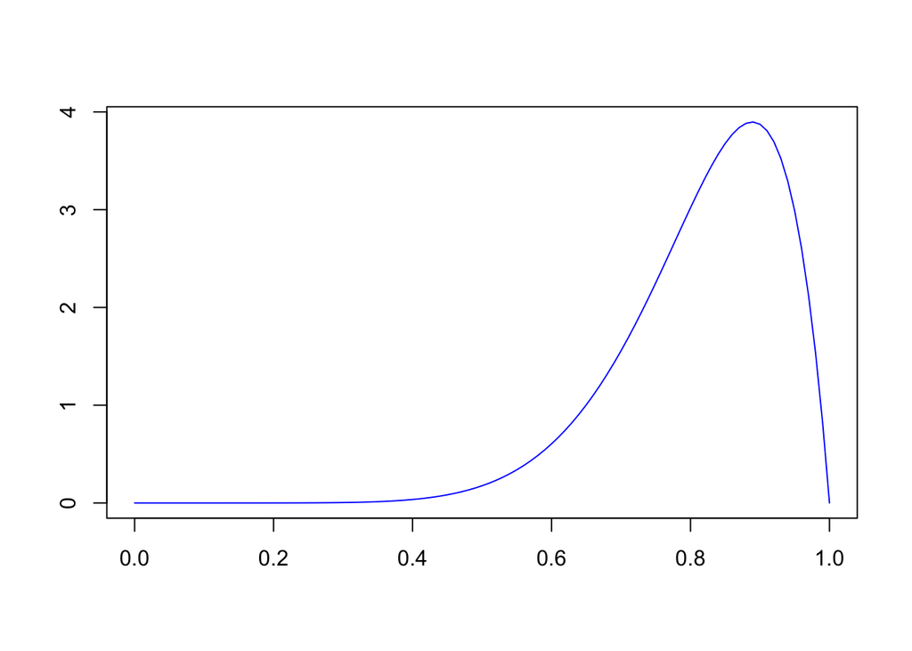

## Cas de la vente à l’unité

Nous allons étudier la variation du profit, du surplus des consommateurs, du surplus total suite à une modification donc du coût marginal.

### Etude des différentes situations

| Type de consommateur | Demande individuelle | Utilité indirecte | Surplus individuel |
| --- | --- | --- | --- |
| 0.6896965 | 0.1392473 | 200.1392 | 0.7694604 |
| 0.7069253 | 0.1427258 | 200.1427 | 0.7886818 |
| 0.8002379 | 0.1615652 | 200.1616 | 0.8927860 |
| 0.8122501 | 0.1639905 | 200.1640 | 0.9061875 |
| 0.8208028 | 0.1657172 | 200.1657 | 0.9157293 |
| 0.8347793 | 0.1685390 | 200.1685 | 0.9313222 |
| 0.8671125 | 0.1750670 | 200.1751 | 0.9673948 |
| 0.8737747 | 0.1764121 | 200.1764 | 0.9748275 |
| 0.8770083 | 0.1770649 | 200.1771 | 0.9784350 |
| 0.8851784 | 0.1787144 | 200.1787 | 0.9875499 |

[output cut: 5 more lines]

Le profit du monopole est identique pour chaque consommateur étant donné que celui-ci ne dépend pas de $\theta$. Afin de déterminer le profit qu’il fait sur l’ensemble des consommateurs, nous allons sommer les profits fait sur chacun des consommateurs.

Le profit du monopole est donc de 0.335.

| Type de consommateur | Demande individuelle | Utilité indirecte | Surplus individuel |
| --- | --- | --- | --- |
| 0.6896965 | 0.1392473 | 200.1392 | 0.6962366 |
| 0.7069253 | 0.1427258 | 200.1427 | 0.7136288 |
| 0.8002379 | 0.1615652 | 200.1616 | 0.8078262 |
| 0.8122501 | 0.1639905 | 200.1640 | 0.8199523 |
| 0.8208028 | 0.1657172 | 200.1657 | 0.8285861 |
| 0.8347793 | 0.1685390 | 200.1685 | 0.8426951 |
| 0.8671125 | 0.1750670 | 200.1751 | 0.8753350 |
| 0.8737747 | 0.1764121 | 200.1764 | 0.8820604 |
| 0.8770083 | 0.1770649 | 200.1771 | 0.8853246 |
| 0.8851784 | 0.1787144 | 200.1787 | 0.8935721 |

[output cut: 5 more lines]

Le profit du monopole est donc de 0.303.

| Type de consommateur | Demande individuelle | Utilité indirecte | Surplus individuel |
| --- | --- | --- | --- |
| 0.6896965 | 0.1392473 | 200.1392 | 0.6299809 |
| 0.7069253 | 0.1427258 | 200.1427 | 0.6457180 |
| 0.8002379 | 0.1615652 | 200.1616 | 0.7309514 |
| 0.8122501 | 0.1639905 | 200.1640 | 0.7419235 |
| 0.8208028 | 0.1657172 | 200.1657 | 0.7497358 |
| 0.8347793 | 0.1685390 | 200.1685 | 0.7625021 |
| 0.8671125 | 0.1750670 | 200.1751 | 0.7920358 |
| 0.8737747 | 0.1764121 | 200.1764 | 0.7981212 |
| 0.8770083 | 0.1770649 | 200.1771 | 0.8010749 |
| 0.8851784 | 0.1787144 | 200.1787 | 0.8085375 |

[output cut: 5 more lines]

Le profit du monopole est donc de 0.274.

Résumé

|  | Prix | Cm | Profit |
| --- | --- | --- | --- |
| Situation 1 | 8 | 2.5 | 0.335 |
| Situation 2 | 8 | 3.0 | 0.303 |
| Situation 3 | 8 | 3.5 | 0.274 |

**De manière générale, on constate qu’au fur et à mesure que le coût marginal augmente (ce qui induit une augmentation du prix), le profit du monopole diminue.**

## Cas de la formule forfaitaire

Nous allons à présent déterminer le prix du forfait en fonction des mêmes coûts marginaux utilisés pour le cas de la vente à l’unité, à savoir : 2.5, 3 et 3.5.

### Etude des différentes situations

Cm=2.5

| Type de consommateur | Forfait | Demande individuelle | Utilité indirecte | Surplus individuel |
| --- | --- | --- | --- | --- |
| 0.8002379 | 3.33 | 0.8002379 | 200.1342 | 0.1335712 |
| 0.8122501 | 3.33 | 0.8122501 | 200.1463 | 0.1455834 |
| 0.8208028 | 3.33 | 0.8208028 | 200.1548 | 0.1541361 |
| 0.8347793 | 3.33 | 0.8347793 | 200.1688 | 0.1681126 |
| 0.8671125 | 3.33 | 0.8671125 | 200.2011 | 0.2004458 |
| 0.8737747 | 3.33 | 0.8737747 | 200.2078 | 0.2071081 |
| 0.8770083 | 3.33 | 0.8770083 | 200.2110 | 0.2103417 |
| 0.8851784 | 3.33 | 0.8851784 | 200.2192 | 0.2185117 |
| 0.9070694 | 3.33 | 0.9070694 | 200.2411 | 0.2404027 |
| 0.9231521 | 3.33 | 0.9231521 | 200.2572 | 0.2564854 |
| 0.9390472 | 3.33 | 0.9390472 | 200.2730 | 0.2723806 |
| 0.9471827 | 3.33 | 0.9471827 | 200.2812 | 0.2805161 |
| 0.9493548 | 3.33 | 0.9493548 | 200.2834 | 0.2826881 |

Le profit du monopole est donc de 5.417.

Cm=3

| Type de consommateur | Forfait | Demande individuelle | Utilité indirecte | Surplus individuel |
| --- | --- | --- | --- | --- |
| 0.8002379 | 3.57 | 0.8002379 | 200.0862 | 0.0859521 |
| 0.8122501 | 3.57 | 0.8122501 | 200.0983 | 0.0979644 |
| 0.8208028 | 3.57 | 0.8208028 | 200.1068 | 0.1065171 |
| 0.8347793 | 3.57 | 0.8347793 | 200.1208 | 0.1204936 |
| 0.8671125 | 3.57 | 0.8671125 | 200.1531 | 0.1528268 |
| 0.8737747 | 3.57 | 0.8737747 | 200.1598 | 0.1594890 |
| 0.8770083 | 3.57 | 0.8770083 | 200.1630 | 0.1627226 |
| 0.8851784 | 3.57 | 0.8851784 | 200.1712 | 0.1708926 |
| 0.9070694 | 3.57 | 0.9070694 | 200.1931 | 0.1927837 |
| 0.9231521 | 3.57 | 0.9231521 | 200.2092 | 0.2088664 |
| 0.9390472 | 3.57 | 0.9390472 | 200.2250 | 0.2247615 |
| 0.9471827 | 3.57 | 0.9471827 | 200.2332 | 0.2328970 |
| 0.9493548 | 3.57 | 0.9493548 | 200.2354 | 0.2350691 |

Le profit du monopole est donc de 3.714.

Cm=3.5

| Type de consommateur | Forfait | Demande individuelle | Utilité indirecte | Surplus individuel |
| --- | --- | --- | --- | --- |
| 0.8671125 | 3.85 | 0.8671125 | 200.0971 | 0.0978817 |
| 0.8737747 | 3.85 | 0.8737747 | 200.1038 | 0.1045440 |
| 0.8770083 | 3.85 | 0.8770083 | 200.1070 | 0.1077776 |
| 0.8851784 | 3.85 | 0.8851784 | 200.1152 | 0.1159476 |
| 0.9070694 | 3.85 | 0.9070694 | 200.1371 | 0.1378386 |
| 0.9231521 | 3.85 | 0.9231521 | 200.1532 | 0.1539213 |
| 0.9390472 | 3.85 | 0.9390472 | 200.1690 | 0.1698165 |
| 0.9471827 | 3.85 | 0.9471827 | 200.1772 | 0.1779520 |
| 0.9493548 | 3.85 | 0.9493548 | 200.1794 | 0.1801240 |

Le profit du monopole est donc de 1.558.

**De manière intuitive, plus le coût marginal augmente plus le forfait est élevé.** **On se rend compte que plus le coût marginal augmente, moins on a de gens qui participent au marché. Cela se traduit par la condition :**
$$\theta \geq \frac{hc + \overline{\theta}}{2}$$
**Plus le prix du forfait est élevé, moins il y a de consommateurs qui participent au marché et ceux qui participent au marché font moins de surplus plus le forfait est élevé.**

**Du côté des producteurs, plus le coût marginal augmente, plus le profit du producteur diminue, cela est probablement dû au fait qu’il y ait moins de consommateurs qui participent au marché.**

## Comparaison des deux stratégies

Nous allons donc comparer les deux stratégies en fonction du coût marginal.

Cm=2.5

|  | Vente à l’unité | Vente forfaitaire |
| --- | --- | --- |
| Profit | 0.3346952 | 5.416667 |
| Surplus consos | 14.3177849 | 2.770284 |
| Surplus social | 14.6524801 | 8.186950 |

Cm=3

|  | Vente à l’unité | Vente forfaitaire |
| --- | --- | --- |
| Profit | 0.3028448 | 3.714286 |
| Surplus consos | 12.9552675 | 2.151236 |
| Surplus social | 13.2581123 | 5.865522 |

Cm=3.5

|  | Vente à l’unité | Vente forfaitaire |
| --- | --- | --- |
| Profit | 0.2740253 | 1.557692 |
| Surplus consos | 11.7224108 | 1.245803 |
| Surplus social | 11.9964361 | 2.803496 |

**Concernant le surplus des consommateurs, on voit qu’il est toujours plus élevé dans le cas de la vente à l’unité que dans le cas de la vente forfaitaire. Cela peut en partie s’expliquer par le fait que tous les individus ne participent pas au marché dans le cas de la vente forfaitaire. Plus le coût marginal augmente, moins il y a d’individus qui participent au marché**

**Concernant le profit du monopole, nous pouvons voir que le profit provenant de la vente forfaitaire est toujours plus élevé par rapport à celui de la vente à l’unité. Cependant, plus le coût marginal augmente, moins l’écart entre les profits des deux stratégies de vente est important. On passe d’un écart de profit de 5.1 pour un Cm=2.5 à un écart de 1.3 pour un coût marginal de 3.5.**

**Cependant, on peut souligner que par rapport à la situation où nous avons une distribution du paramètre de goût suivant une loi uniforme sur [0,1], il y a plus de gens qui participent au marché pour la vente forfaitaire lorsque le coût augmente. Cela s’explique par la différence de distribution de ces 2 lois. En effet, la loi beta (9,2) suit distribution disymétrique vers la droite. Les valeurs ne sont donc pas uniformément réparties mais plutôt concentrées autour de [0.6,0.9]**

## Vente à l’unité et à volonté

### Choix de la formule par les consommateurs

On détermine tout d’abord le consommateur indifférent. Ce dernier nous permettra de distinguer les individus qui préfèrent la vente à l’unité ou la vente forfaitaire.

$$\begin{aligned}
\overline{\theta} = \frac{hA}{1-exp(-hp)}
\end{aligned}$$

Nous nous plaçons dans la situation où le cout marginal = $3$ et le prix optimal $p$ = 8 et le forfait $A$ = 3.57.

Notre consommateur indifférent est donc : $\overline{\theta}$ = 0.8946208

Etant donné les préférences de nos consommateurs, 10 consommateurs choisissent la vente à l’unité et seulement 5 la vente à volonté.

A l’unité

| Type de consommateur | Demande individuelle |
| --- | --- |
| 0.6896965 | 0.1392473 |
| 0.7069253 | 0.1427258 |
| 0.8002379 | 0.1615652 |
| 0.8122501 | 0.1639905 |
| 0.8208028 | 0.1657172 |
| 0.8347793 | 0.1685390 |
| 0.8671125 | 0.1750670 |
| 0.8737747 | 0.1764121 |
| 0.8770083 | 0.1770649 |
| 0.8851784 | 0.1787144 |

A volonté

| Type de consommateur | Demande individuelle |
| --- | --- |
| 0.9070694 | 0.9070694 |
| 0.9231521 | 0.9231521 |
| 0.9390472 | 0.9390472 |
| 0.9471827 | 0.9471827 |
| 0.9493548 | 0.9493548 |

### Problème du monopole

Nous avons testé des valeurs de prix égales à 7.5,8 et 8.5 avec un coût marginal égal à 3. Suite à cela, nous avons déterminé le forfait optimal et ainsi calculé le profit du monopole dans les trois situations.

Tarification optimale

|  | Prix optimal | Forfait optimal | Profit |
| --- | --- | --- | --- |
| Situation 1 | 7.5 | 3.900285 | 12.92470 |
| Situation 2 | 8.0 | 3.870919 | 13.60239 |
| Situation 3 | 8.5 | 3.825263 | 14.19864 |